# SEM 1

Simon Roth

21.4.2017

# Datensatz einladen

1. german: Staatsbürgerschaft
- 1 Ja, ausschließlich
- 2 Ja, neben 2. Staatsbürgerschaft
- 3 Nein
2. eastwest: Erhebungsgebiet
- 1 West
- 2 Ost

## Itembatterien

**Islamophobie:**

- mm01: ISLAMAUSUEBUNG IN BRD BESCHRAENKEN
  - -10 Befragter gehört einer islamischen Religionsgemeinschaft an (Code 1 in rd03)
  - -9
  - 1 Stimme überhaupt nicht zu
  - 2
  - 3
  - 4
  - 5
  - 6
  - 7 Stimme voll und ganz zu
- mm02: ISLAM PASST IN DIE DEUTSCHE GESELLSCHAFT
- mm03: ANWESENHEIT VON MUSLIMEN BRINGT KONFLIKT
- mm04: STAAT SOLLTE ISLAM. GRUPPEN BEOBACHTEN
- mm05: MUSLIMISCHER BUERGERMEISTER IN ORDNUNG
- mm06: UNTER MUSLIMEN SIND VIELE REL. FANATIKER

**Deutschein:**

- mn11: DEUTSCH SEIN: DEUTSCHE STAATSBUERGERSCH.
- mn12: DEUTSCH SEIN: CHRISTL.RELIGION ZUGEHOER.
- mn13: DEUTSCH SEIN: BEKENNTNIS ZUR DEMOKRATIE
- mn14: DEUTSCH SEIN: VIELE DEUTSCHE BEKANNTE
- mn15: DEUTSCH SEIN: ALTE STAATSANGEH.AUFGEBEN
- mn16: DEUTSCH SEIN: VERBUNDENHEIT ZU DEUTSCHL.
- mn17: DEUTSCH SEIN: ALTE GEBRAEUCHE ABLEGEN
- mn18: DEUTSCH SEIN: GUT DEUTSCH SPRECHEN
- mn19: DEUTSCH SEIN: WESTLICHE WERTE TEILEN
- mn20: DEUTSCH SEIN: MIND. 1 ELTERNTEIL DEUTSCH
- mn21: DEUTSCH SEIN: IN DEUTSCHLAND GEBOREN

# Daten partitionieren

- sex: GESCHLECHT (Int.: Geschlecht der befragten Person ohne Befragen eintragen!)
  - 1 Männlich
  - 2 Weiblich
- age: ALTER: metrisch
- agec: ALTER: KATEGORISIERT 6
  - 18 - 29 Jahre
  - 30 - 44 Jahre
  - 45 - 59 Jahre
  - 60 - 74 Jahre
  - 75 - 89 Jahre
  - Über 89 Jahre
- isced97: BEFR.: ISCED 1997 - 6 STUFEN: International Standard Classification of Education (ISCED) 1997, 6 Stufen
  1. Level - Primary education or first stage of basic education
  2. Level - Lower secondary or second stage of basic education
  3. Level - (Upper) secondary education
  4. Level - Post-secondary non-tertiary education
  5. Level - First stage of tertiary education
  6. Level - Second stage of tertiary education

# Visualisierungen

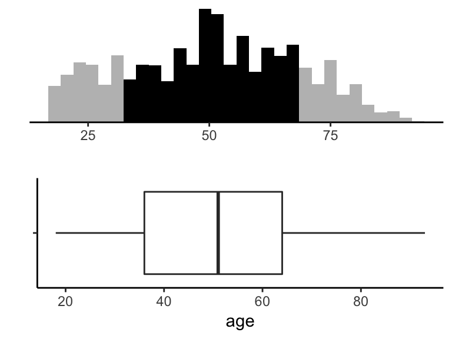

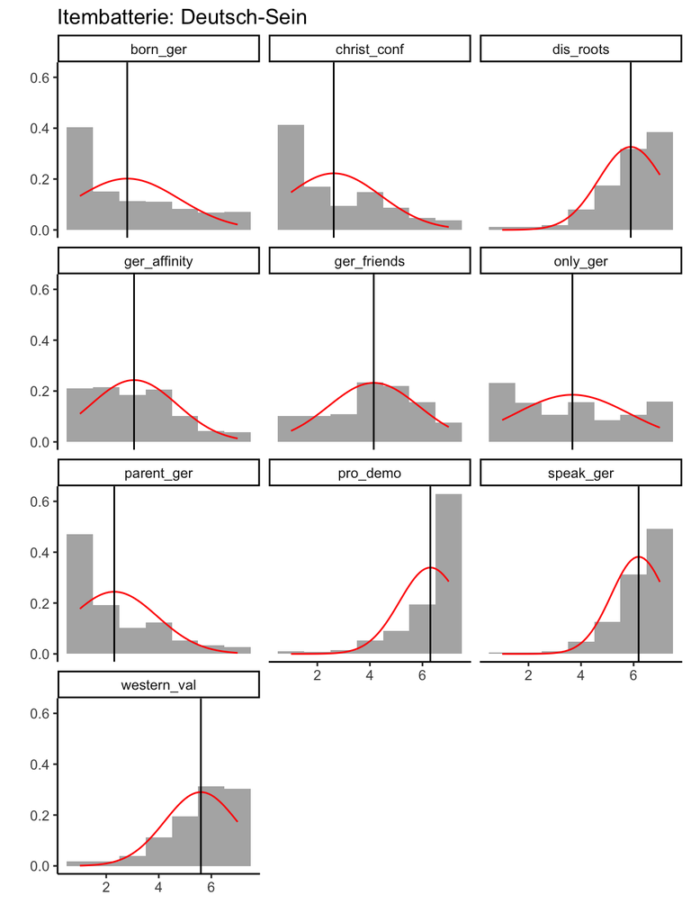

*Wie wichtig sind die folgenden Dinge, damit Sie sagen würden, dass eine Person mit ausländischen Wurzeln ein wirklicher Deutscher/eine wirkliche Deutsche wird?*. Religiöse sowie ethnische Voraussetzungen scheinen für die Mehrheit der Befragten irrelevant. Entscheidend sind hingegen kulturelle Faktoren, wie Demokratieverständnis und soziale Assimilation. Nur 2 von 10 Variablen sind annäherend normalverteilt und weisen ansonst eine Tendenz zu den Skalenrändern auf.

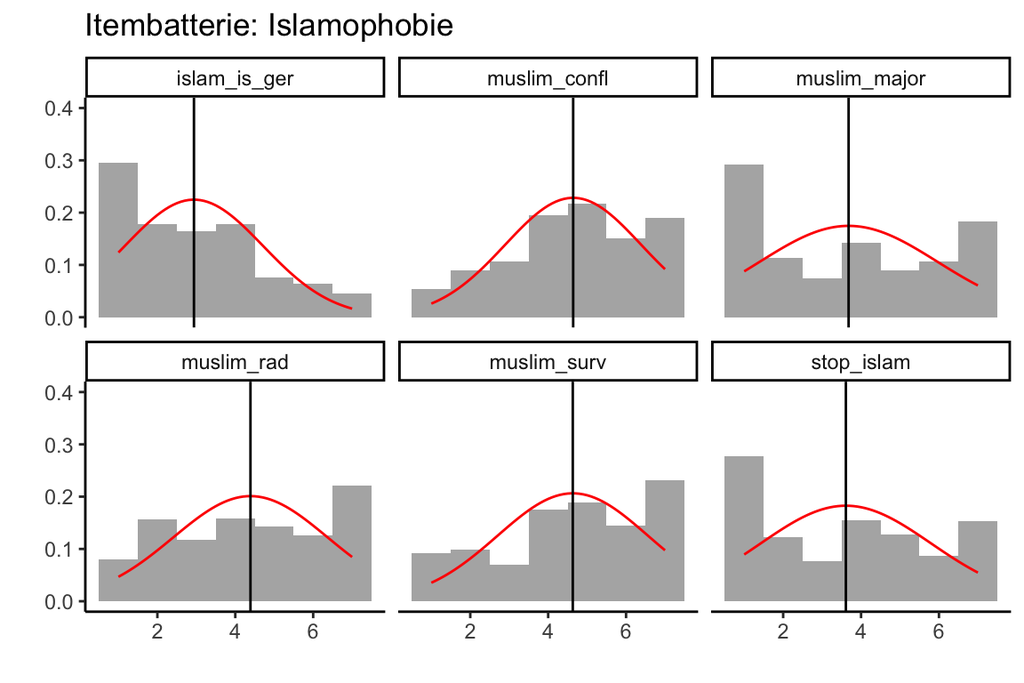

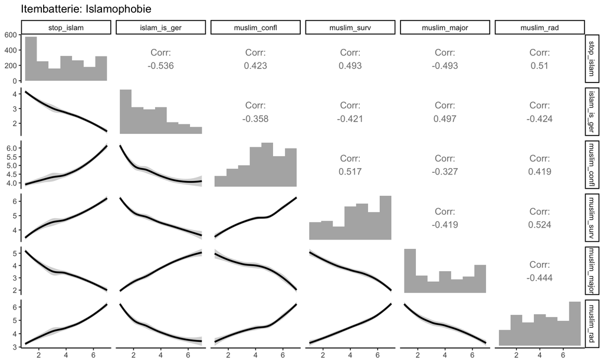

Pearson’s correlation matrix

|  | age | isced97 | ger_citiz | christ_conf | pro_demo | ger_friends | only_ger | dis_roots | ger_affinity | speak_ger | western_val | parent_ger | born_ger | stop_islam | islam_is_ger | muslim_confl | muslim_surv | muslim_major | muslim_rad |
| --- | --- | --- | --- | --- | --- | --- | --- | --- | --- | --- | --- | --- | --- | --- | --- | --- | --- | --- | --- |
| age | 1 | 0 | 0.11 | 0.17 | 0.12 | 0.13 | 0.21 | 0.14 | 0.12 | 0.09 | 0.18 | 0.14 | 0.13 | 0.16 | -0.18 | 0.11 | 0.26 | -0.16 | 0.3 |
| isced97 |  | 1 | -0.09 | -0.12 | 0.14 | 0.03 | -0.14 | 0.03 | -0.18 | -0.03 | -0.04 | -0.17 | -0.17 | -0.2 | 0.17 | -0.1 | -0.15 | 0.21 | -0.22 |
| ger_citiz |  |  | 1 | 0.19 | 0.29 | 0.1 | 0.36 | 0.27 | 0.2 | 0.22 | 0.3 | 0.12 | 0.18 | 0.13 | -0.15 | 0.18 | 0.18 | -0.11 | 0.17 |
| christ_conf |  |  |  | 1 | -0.01 | 0.32 | 0.26 | 0.08 | 0.39 | 0.03 | 0.22 | 0.55 | 0.42 | 0.38 | -0.27 | 0.24 | 0.32 | -0.32 | 0.33 |
| pro_demo |  |  |  |  | 1 | 0.15 | 0.08 | 0.33 | -0.01 | 0.25 | 0.33 | -0.09 | -0.08 | -0.05 | 0.06 | 0.06 | 0.06 | 0.06 | -0.01 |
| ger_friends |  |  |  |  |  | 1 | 0.08 | 0.26 | 0.17 | 0.16 | 0.25 | 0.24 | 0.2 | 0.09 | 0 | 0.14 | 0.16 | -0.07 | 0.1 |
| only_ger |  |  |  |  |  |  | 1 | 0.22 | 0.45 | 0.12 | 0.25 | 0.27 | 0.28 | 0.3 | -0.27 | 0.21 | 0.26 | -0.3 | 0.31 |
| dis_roots |  |  |  |  |  |  |  | 1 | 0.09 | 0.39 | 0.39 | 0.01 | 0.05 | 0.05 | 0.01 | 0.17 | 0.15 | -0.04 | 0.08 |
| ger_affinity |  |  |  |  |  |  |  |  | 1 | 0.12 | 0.23 | 0.42 | 0.36 | 0.43 | -0.32 | 0.26 | 0.31 | -0.38 | 0.36 |
| speak_ger |  |  |  |  |  |  |  |  |  | 1 | 0.43 | -0.03 | 0.01 | 0.08 | -0.1 | 0.17 | 0.16 | -0.05 | 0.16 |
| western_val |  |  |  |  |  |  |  |  |  |  | 1 | 0.12 | 0.1 | 0.2 | -0.18 | 0.2 | 0.26 | -0.17 | 0.23 |
| parent_ger |  |  |  |  |  |  |  |  |  |  |  | 1 | 0.65 | 0.33 | -0.23 | 0.23 | 0.28 | -0.28 | 0.3 |
| born_ger |  |  |  |  |  |  |  |  |  |  |  |  | 1 | 0.3 | -0.22 | 0.19 | 0.27 | -0.27 | 0.28 |
| stop_islam |  |  |  |  |  |  |  |  |  |  |  |  |  | 1 | -0.54 | 0.42 | 0.49 | -0.49 | 0.51 |
| islam_is_ger |  |  |  |  |  |  |  |  |  |  |  |  |  |  | 1 | -0.36 | -0.42 | 0.5 | -0.42 |
| muslim_confl |  |  |  |  |  |  |  |  |  |  |  |  |  |  |  | 1 | 0.52 | -0.33 | 0.42 |
| muslim_surv |  |  |  |  |  |  |  |  |  |  |  |  |  |  |  |  | 1 | -0.42 | 0.52 |
| muslim_major |  |  |  |  |  |  |  |  |  |  |  |  |  |  |  |  |  | 1 | -0.44 |
| muslim_rad |  |  |  |  |  |  |  |  |  |  |  |  |  |  |  |  |  |  | 1 |

Wie die Korrelationstabelle deutlich offen legt gibt es einen linearen Zusammenhang zwischen Alter und der islamophobischen Eeinstellungen. Während die Korrelation für die Itembatterie: Islamophobie sinnvoll interpretiert werden kann, liegen bei den *Deutsch-Sein* Variablen oft eine non-lineare Assoziation vor, wodurch Pearson-R seine Aussagekraft verliert.